# Tutorial 6. TF Activity Analysis Using the snATAC-seq Data

Iguaracy Souza, Thodoris Koutsandreas, and Umran Yaman

### 1. Loading of the snATAC-seq data

```r
snATAC_qc_seurat_obj <- readRDS("../data/snATAC_qc_seurat_obj.rds")
DefaultAssay(snATAC_qc_seurat_obj) <- "ATAC"
Idents(snATAC_qc_seurat_obj) <- snATAC_qc_seurat_obj$Celltype1
```

### 2. Binding Sites of Transcription Factors

The binding sites for transcription factors (in the form of motifs) will be retrieved from the JASPAR database. JASPAR contains curated, non-redundant and experimentally defined sets of transcription factor binding sites for eukaryotes. This information will be used to detect the sequence ranges on the genome which match with these motifs, identifying in this way the binding sites of TFs and the genes that correspond to the matched sequence ranges.

```r
# Get a position frequency matrices (PFMs) object from the JASPAR database 9606 is the NCBI
# Taxonomy ID for Homo sapiens
position_freq_matrices <- getMatrixSet(x = JASPAR2020, opts = list(species = 9606, all_versions = FALSE))

# The following command scans the DNA sequence of each peak (sequence range), using the genome
# data, to identify for the presence of each motif and store that information in the the
# Seurat object.
snATAC_qc_seurat_obj <- AddMotifs(snATAC_qc_seurat_obj, pfm = position_freq_matrices, genome = BSgenome.Hsapiens.UCSC.hg38)
```

Plot of TF binding sites (motifs).

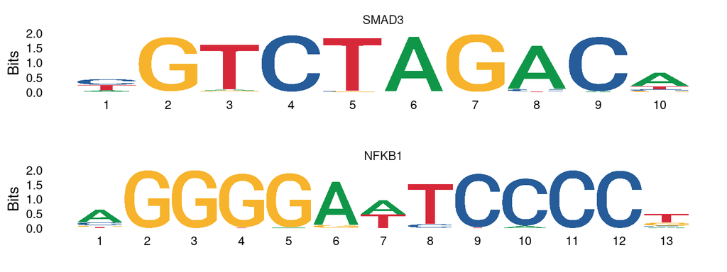

```r
motifs <- Motifs(snATAC_qc_seurat_obj)

motif_id <- ConvertMotifID(motifs, name = "SMAD3")
p1 <- MotifPlot(snATAC_qc_seurat_obj, motifs = motif_id)

motif_id <- ConvertMotifID(motifs, name = "NFKB1")
p2 <- MotifPlot(snATAC_qc_seurat_obj, motifs = motif_id)

ggarrange(p1, p2, ncol = 1, nrow = 2)
```

Find the matched sequence ranges on the genome for a given TF.

```r
motif_id <- ConvertMotifID(motifs, name = "SMAD3")
ranges <- motifs@data[, motif_id]
matched_ranges <- ranges[ranges == TRUE]

print(paste("Sequences ranges in genome:", length(ranges), sep = " "))
```

```
## [1] "Sequences ranges in genome: 363775"
```

```r
print(paste("Matched sequences for SMAD3:", length(matched_ranges), sep = " "))
```

```
## [1] "Matched sequences for SMAD3: 5963"
```

### 3. Differential TF activity analysis

The analysis will be performed for each pathological condition Thus, the dataset should be separated according to this factor.

```r
snATAC_by_condition <- SplitObject(snATAC_qc_seurat_obj, split.by = "Pathology")
```

Firstly the FindMarkers() function will be used to perform differential analysis in order to identify peaks that are significantly differentially accessible between cell types for each condition.

```r
peaks_list <- list()

for (condition in names(snATAC_by_condition)) {

    condition_seurat_obj <- snATAC_by_condition[[condition]]
    cell_types <- unique(condition_seurat_obj@meta.data$Celltype1)

    # Loop through each cell type
    for (cell_type in cell_types) {
        # Check the number of cells in this cell type
        num_cells <- sum(condition_seurat_obj@meta.data$Celltype1 == cell_type)
        if (num_cells < 10) {
            next  # Skip to the next cell type
        }
        # Perform differential expression analysis
        peaks_df <- FindMarkers(condition_seurat_obj, ident.1 = cell_type, only.pos = TRUE, test.use = "LR",
            min.pct = 0.2, latent.vars = "nCount_ATAC")
        peaks_df <- peaks_df[(peaks_df$p_val_adj < 0.05 & peaks_df$avg_log2FC > 0.5), ]
        if (dim(peaks_df)[1] > 1500) {
            # Be stricter
            peaks_df <- peaks_df[(peaks_df$p_val_adj < 0.05 & peaks_df$avg_log2FC > 1), ]
        }
        peaks_list[[paste(condition, cell_type, sep = "_")]] <- peaks_df
        print(paste(condition, cell_type, dim(peaks_df)[1]))
    }
}
```

```
## [1] "non_AD Astrocytes 1016"
## [1] "non_AD Excitatory_neurons 22"
## [1] "non_AD Inhibitory_neurons 57"
## [1] "non_AD Microglia 1243"
## [1] "non_AD Oligodendrocytes 876"
## [1] "non_AD Oligodendrocyte_progenitor_cells 1205"
## [1] "non_AD Vascular 48"
## [1] "early_AD Astrocytes 1469"
## [1] "early_AD Excitatory_neurons 47"
## [1] "early_AD Inhibitory_neurons 50"
## [1] "early_AD Microglia 866"
## [1] "early_AD Oligodendrocytes 1003"
## [1] "early_AD Oligodendrocyte_progenitor_cells 1407"
## [1] "early_AD Vascular 55"
## [1] "late_AD Astrocytes 653"
## [1] "late_AD Excitatory_neurons 5"
## [1] "late_AD Inhibitory_neurons 15"
```

```
## [1] "late_AD Microglia 604"
## [1] "late_AD Oligodendrocytes 885"
## [1] "late_AD Oligodendrocyte_progenitor_cells 559"
## [1] "late_AD Vascular 78"
```

Secondly, the FindMotifs() function will be used to identify those motifs that are over-represented in the set of differentially accessible peaks in each condition and cell type. In other words, this function will reveal those TFs whose activity is probably deregulated, based on the differentiated accessibility on the respective sites on the genome.

```r
enriched_motifs <- list()

for (key in names(peaks_list)) {

    condition <- paste(strsplit(key, split = "_")[[1]][1:2], collapse = "_")
    condition_seurat_obj <- snATAC_by_condition[[condition]]
    background <- rownames(condition_seurat_obj)
    da_peaks <- rownames(peaks_list[[key]])

    motifs_df <- FindMotifs(object = condition_seurat_obj, features = da_peaks, background = background)
    motifs_df <- motifs_df[(motifs_df$p.adjust < 0.1 & motifs_df$fold.enrichment > 2), ]
    enriched_motifs[[key]] <- motifs_df
}

# Save the enriched_motifs list in the 'results' folder
saveRDS(enriched_motifs, "../results/tf_results.rds")
```